# Experiment 1: Reaction Time Analyses

### Stats

Reaction time is modeled as a linear effect of field, level, and handedness, using data from every target-present trial with a “go” response:  
`lmer( rt ~ field*level*handedness + (1 | subject) )`

Experiment 1: Field by Level by Handedness (RT)

ANOVA: compare models with vs. without interaction term

| npar | AIC | BIC | logLik | deviance | Chisq | Df | p.value<sup>1</sup> |
| --- | --- | --- | --- | --- | --- | --- | --- |
| 9 | 1,166,282.858 | 1,166,367.139 | −583,132.429 | 1,166,264.858 | - | - | - |
| 10 | 1,166,280.551 | 1,166,374.197 | −583,130.276 | 1,166,260.551 | 4.307 | 1 | .038 |

<sup>1</sup> F-test (two-sided? https://daniellakens.blogspot.com/2016/04/one-sided-f-tests-and-halving-p-values.html)

Experiment 1: Field by Level by Handedness (RT)

Compare effect estimate to zero with emmeans()

| field_consec | level_consec | handedness_consec | estimate<sup>1</sup> | SE | df<sup>2</sup> | lower.CL<sup>3</sup> | upper.CL<sup>3</sup> | t.ratio | p.value<sup>4</sup> |
| --- | --- | --- | --- | --- | --- | --- | --- | --- | --- |
| LVF - RVF | Local - Global | Right - Left | 11.666 | 5.622 | 85,499.255 | 0.648 | 22.685 | 2.075 | .038 |

<sup>1</sup> A positive number means LVF global bias is stronger in right handers (as predicted by AAH)  
<sup>2</sup> Z-approximation  
<sup>3</sup> Confidence level: 95%  
<sup>4</sup> Two-sided

Experiment 1: Field by Level (by Handedness) (RT)

| field_consec | level_consec | handedness | estimate<sup>1</sup> | SE | df<sup>2</sup> | lower.CL<sup>3</sup> | upper.CL<sup>3</sup> | t.ratio | p.value<sup>4</sup> |
| --- | --- | --- | --- | --- | --- | --- | --- | --- | --- |
| LVF - RVF | Local - Global | Left | 15.641 | 4.107 | 85,499.426 | 7.592 | 23.69 | 3.809 | .0001 |
| LVF - RVF | Local - Global | Right | 27.307 | 3.839 | 85,499.059 | 19.783 | 34.832 | 7.113 | <.0001 |

<sup>1</sup> A positive number means global bias (faster RT for global)  
<sup>2</sup> Z-approximation  
<sup>3</sup> Confidence level: 95%  
<sup>4</sup> Two-sided, uncorrected

Experiment 1: Field by Handedess (by Level) (RT)

| field_consec | handedness_consec | level | estimate<sup>1</sup> | SE | df<sup>2</sup> | lower.CL<sup>3</sup> | upper.CL<sup>3</sup> | t.ratio | p.value<sup>4</sup> |
| --- | --- | --- | --- | --- | --- | --- | --- | --- | --- |
| LVF - RVF | Right - Left | Global | 10.27 | 3.945 | 85,498.911 | 2.537 | 18.004 | 2.603 | .009 |
| LVF - RVF | Right - Left | Local | 21.937 | 4.005 | 85,499.534 | 14.088 | 29.786 | 5.478 | <.0001 |

<sup>1</sup> A positive number means more RVF bias for right handers  
<sup>2</sup> Z-approximation  
<sup>3</sup> Confidence level: 95%  
<sup>4</sup> Two-sided, uncorrected

LVF Global bias by handedness bin (RT)

| contrast | handedness | level | estimate<sup>1</sup> | SE | df<sup>2</sup> | lower.CL<sup>3</sup> | upper.CL<sup>3</sup> | t.ratio | p.value<sup>4</sup> |
| --- | --- | --- | --- | --- | --- | --- | --- | --- | --- |
| LVF - RVF | Left | Global | −25.295 | 2.879 | 85,498.972 | −30.938 | −19.652 | −8.786 | <.0001 |
| LVF - RVF | Left | Local | −9.654 | 2.928 | 85,499.742 | −15.393 | −3.914 | −3.297 | .001 |
| LVF - RVF | Right | Global | −15.024 | 2.698 | 85,498.841 | −20.312 | −9.737 | −5.569 | <.0001 |
| LVF - RVF | Right | Local | 12.283 | 2.732 | 85,499.295 | 6.929 | 17.637 | 4.497 | <.0001 |

<sup>1</sup> A positive number means global bias (faster RT for global)  
<sup>2</sup> Z-approximation  
<sup>3</sup> Confidence level: 95%  
<sup>4</sup> Two-sided, uncorrected

### Plots

Diamonds and lineranges show mixed-effects model point estimates and 95% CI.

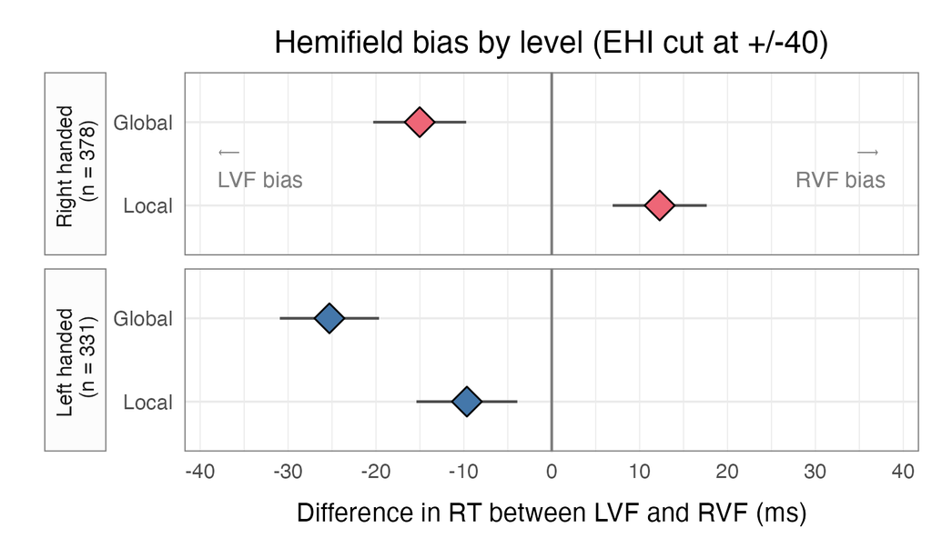

## Categorical handedness (exploratory - EHI +/-100)

### Summary

Limiting analysis to strong left and right handers with EHI scores of +/-100, left handers’ LVF>RVF global bias was reduced by 23.52ms (95% CI [7.10, 39.93], $\chi^2(1)$ = 7.89, = .005, two-sided). Strong right handers showed significant LVF>RVF global bias (28.10ms, 95% CI [17.34, 38.86], (38,617.45) = 5.12, < .0001, two-sided); whereas strong left handers showed no significant interaction of field by level (4.59ms, 95% CI [-7.81, 16.98], (38,617.6) = 0.73, = .47, two-sided).

Within the local level, strong right and left handers showed reversed hemifield bias: right handers responded faster to local stimuli in the RVF than LVF by 13.56ms (95% CI [5.90, 21.22], (38,617.6) = 3.47, = .0005, two-sided), whereas left handers responded faster to local stimuli in the LVF than RVF by 18.09ms (95% CI [9.25, 26.93], (38,617.69) = 4.01 < .0001, two-sided; difference = 31.65ms, 95% CI [19.96, 43.35], (38,617.67) = 5.30, < .0001, two-sided).

### Stats

Reaction time is modeled as a linear effect of field, level, and handedness, using data from every target-present trial with a “go” response:  
`lmer( rt ~ field*level*handedness + (1 | subject) )`

Experiment 1: Field by Level by Handedness (RT)

ANOVA: compare models with vs. without interaction term

| npar | AIC | BIC | logLik | deviance | Chisq | Df | p.value<sup>1</sup> |
| --- | --- | --- | --- | --- | --- | --- | --- |
| 9 | 526,319.708 | 526,396.837 | −263,150.854 | 526,301.708 | - | - | - |
| 10 | 526,313.82 | 526,399.519 | −263,146.91 | 526,293.82 | 7.888 | 1 | .005 |

<sup>1</sup> F-test (two-sided? https://daniellakens.blogspot.com/2016/04/one-sided-f-tests-and-halving-p-values.html)

Experiment 1: Field by Level by Handedness (RT)

Compare effect estimate to zero with emmeans()

| field_consec | level_consec | handedness_consec | estimate<sup>1</sup> | SE | df<sup>2</sup> | lower.CL<sup>3</sup> | upper.CL<sup>3</sup> | t.ratio | p.value<sup>4</sup> |
| --- | --- | --- | --- | --- | --- | --- | --- | --- | --- |
| LVF - RVF | Local - Global | Right - Left | 23.514 | 8.373 | 38,617.511 | 7.103 | 39.925 | 2.808 | .005 |

<sup>1</sup> A positive number means LVF global bias is stronger in right handers (as predicted by AAH)  
<sup>2</sup> Z-approximation  
<sup>3</sup> Confidence level: 95%  
<sup>4</sup> Two-sided

Experiment 1: Field by Level (by Handedness) (RT)

| field_consec | level_consec | handedness | estimate<sup>1</sup> | SE | df<sup>2</sup> | lower.CL<sup>3</sup> | upper.CL<sup>3</sup> | t.ratio | p.value<sup>4</sup> |
| --- | --- | --- | --- | --- | --- | --- | --- | --- | --- |
| LVF - RVF | Local - Global | Left | 4.587 | 6.322 | 38,617.558 | −7.805 | 16.979 | 0.726 | .468 |
| LVF - RVF | Local - Global | Right | 28.101 | 5.489 | 38,617.45 | 17.342 | 38.86 | 5.119 | <.0001 |

<sup>1</sup> A positive number means global bias (faster RT for global)  
<sup>2</sup> Z-approximation  
<sup>3</sup> Confidence level: 95%  
<sup>4</sup> Two-sided, uncorrected

Experiment 1: Field by Handedess (by Level) (RT)

| field_consec | handedness_consec | level | estimate<sup>1</sup> | SE | df<sup>2</sup> | lower.CL<sup>3</sup> | upper.CL<sup>3</sup> | t.ratio | p.value<sup>4</sup> |
| --- | --- | --- | --- | --- | --- | --- | --- | --- | --- |
| LVF - RVF | Right - Left | Global | 8.138 | 5.873 | 38,617.388 | −3.373 | 19.649 | 1.386 | .166 |
| LVF - RVF | Right - Left | Local | 31.652 | 5.968 | 38,617.669 | 19.956 | 43.349 | 5.304 | <.0001 |

<sup>1</sup> A positive number means more RVF bias for right handers  
<sup>2</sup> Z-approximation  
<sup>3</sup> Confidence level: 95%  
<sup>4</sup> Two-sided, uncorrected

LVF Global bias by handedness bin (RT)

| contrast | handedness | level | estimate<sup>1</sup> | SE | df<sup>2</sup> | lower.CL<sup>3</sup> | upper.CL<sup>3</sup> | t.ratio | p.value<sup>4</sup> |
| --- | --- | --- | --- | --- | --- | --- | --- | --- | --- |
| LVF - RVF | Left | Global | −22.681 | 4.431 | 38,617.407 | −31.366 | −13.995 | −5.118 | <.0001 |
| LVF - RVF | Left | Local | −18.093 | 4.51 | 38,617.692 | −26.932 | −9.254 | −4.012 | <.0001 |
| LVF - RVF | Right | Global | −14.542 | 3.855 | 38,617.363 | −22.098 | −6.987 | −3.773 | .0002 |
| LVF - RVF | Right | Local | 13.559 | 3.908 | 38,617.639 | 5.898 | 21.219 | 3.469 | .0005 |

<sup>1</sup> A positive number means global bias (faster RT for global)  
<sup>2</sup> Z-approximation  
<sup>3</sup> Confidence level: 95%  
<sup>4</sup> Two-sided, uncorrected

### Plots

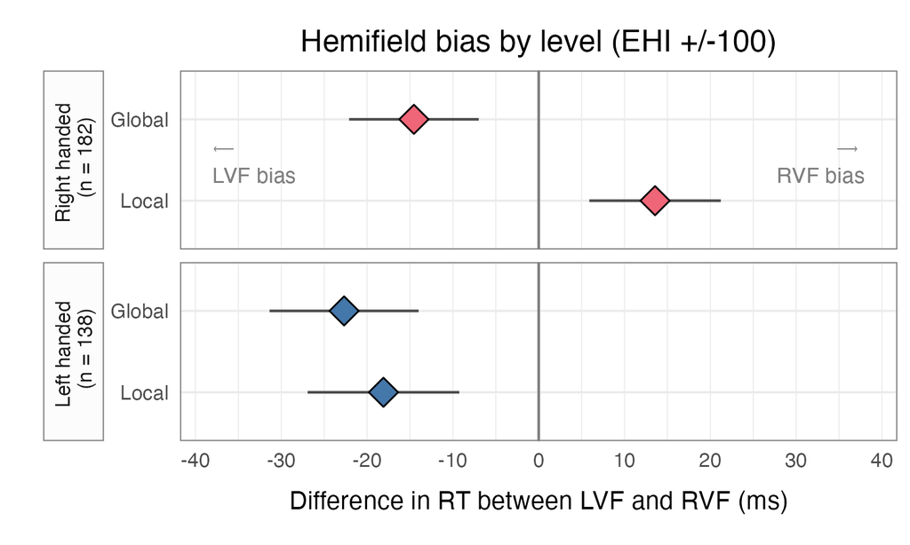